# Assignment 1 Submission

Himakar Gadham & Atikanth Jain

Apirl 18, 2024

## Assignment 1 submitted by Student Name, Student ID

Himakar Gadham - 23783777, Atikant Jain -

### Statemenf of Contribution should be written here if pairing. State what each team member has contributed to the assignment before answering the questions. Each student must contribute towards ALL questions. Your assignment will not be marked without this statement.

Both contributed equally to all the questions. We both sat together in library and worked through each question.

## Question 1 Normal distribution. (8 marks)

1. (1 mark) Find the probability that the user spends more than 15 minutes per month at the site.

```r
mean <- 25
std_dev <- 4.0

prob_more_than_15 <- 1 - pnorm(15, mean, std_dev)
cat("(a) Probability that the user spends more than 15 minutes per month:", round(prob_more_than_15, 4), "\n")
```

[output not shown]

2. (2 marks) Find the probability that the user spends between 20 and 35 minutes per month at the site.

```r
prob_between_20_and_35 <- pnorm(35, mean, std_dev) - pnorm(20, mean, std_dev)
cat("(b) Probability that the user spends between 20 and 35 minutes per month:", round(prob_between_20_and_35, 4), "\n")
```

[output not shown]

3. (2 marks) What is the amount of time per month a user spends on Facebook, if only 1% of users spend this time or longer on Facebook?

```r
time_for_1_percent <- qnorm(0.99, mean, std_dev)
cat("(c) Time per month a user spends on Facebook if only 1% of users spend this time or longer:", round(time_for_1_percent, 4), "minutes\n")
```

[output not shown]

4. (3 marks) Between what values do the time spent of the middle 90% distribution of Facebook users fall?

```r
time_middle_90_lower <- qnorm(0.05, mean, std_dev)
time_middle_90_upper <- qnorm(0.95, mean, std_dev)
cat("(d) Time spent by the middle 90% of distribution of Facebook users:", round(time_middle_90_lower, 4), "to", round(time_middle_90_upper, 4), "minutes\n")
```

[output not shown]

## Question 2 Blood fat concentration (11 marks)

1. (6 marks) Conduct a two-independent sample $t$-test using R to determine whether the concentration of plasma cholesterol is significantly different between patients with no evidence of heart disease and those with narrowing of the arteries.

```r
# Define summary statistics for each group
mean_no_disease <- 195.2745
var_no_disease <- 1303.9231
n_no_disease <- 51

mean_disease <- 216.1906
var_disease <- 1850.2488
n_disease <- 320

# Calculate the test statistic
t_stat <- (mean_no_disease - mean_disease) / sqrt((var_no_disease / n_no_disease) + (var_disease / n_disease))

# Calculate degrees of freedom using Welch's approximation
df <- ((var_no_disease / n_no_disease) + (var_disease / n_disease))^2 /
      ((var_no_disease^2 / (n_no_disease^2 * (n_no_disease - 1))) +
       (var_disease^2 / (n_disease^2 * (n_disease - 1))))

# Conduct a two-tailed test
p_value <- 2 * pt(abs(t_stat), df = df, lower.tail = FALSE)

# Print the test statistic, degrees of freedom, and p-value
cat("Test Statistic:", t_stat, "\n")
```

```
Test Statistic: -3.735664
```

```r
cat("Degrees of Freedom:", df, "\n")
```

```
Degrees of Freedom: 74.57449
```

```r
cat("p-value:", p_value, "\n")
```

```
p-value: 0.0003640548
```

1. **State the hypotheses**:
   - Null Hypothesis ($H_0$): There is no difference in mean plasma cholesterol concentration between the two groups. $H_0: \mu_1 = \mu_2$
   - Alternative Hypothesis ($H_1$): There is a difference in mean plasma cholesterol concentration between the two groups. $H_1: \mu_1 \neq \mu_2$
2. **Calculate the test statistic**:
   - Given test statistic $t = -3.735664$
3. **Determine the sampling distribution**:
   - Degrees of Freedom ($df$): 74.57449
4. **Determine the $p$-value**:
   - $p\text{-value} = 0.0003640548$
5. **Interpretation of $p$-value**:
   - $p$-value $< 0.01$: Reject the null hypothesis
6. **Conclusion**:
   - Since the $p$-value ($0.0003640548$) is less than the significance level of $0.05$, we reject the null hypothesis.
   - There is evidence to suggest that there is a significant difference in mean plasma cholesterol concentration between patients with no evidence of heart disease and those with narrowing of the arteries.
2. (3 marks) Determine a 99% confidence interval for the mean difference in concentration of plasma cholesterol between the two groups of patients.

```r
# Calculate the margin of error
margin_of_error <- qt(0.995, df) * sqrt(var_no_disease/n_no_disease + var_disease/n_disease)

# Calculate the confidence interval
lower_bound <- (mean_no_disease - mean_disease) - margin_of_error
upper_bound <- (mean_no_disease - mean_disease) + margin_of_error

# Print the results
cat("99% Confidence Interval for the Mean Difference in Concentration of Plasma Cholesterol:\n")
```

```
99% Confidence Interval for the Mean Difference in Concentration of Plasma Cholesterol:
```

```r
cat("(", lower_bound, ",", upper_bound, ")\n")
```

```
( -35.71644 , -6.115758 )
```

3. (2 marks) Explain the correspondence between the confidence interval in (b) and a test of the hypotheses you listed in question (a).

The confidence interval in (b) provides a range of values within which we are confident the true difference in mean plasma cholesterol concentration between the two groups of patients lies. In this case, the interval (-35.71644, -6.115758) suggests that we are 99% confident that the true difference falls between these two values.

The test of hypotheses listed in question (a) involves testing whether there is a significant difference in mean plasma cholesterol concentration between the two groups of patients. The null hypothesis (H0) states that there is no difference in mean plasma cholesterol concentration between the two groups, while the alternative hypothesis (H1) states that there is a difference.

The correspondence between the confidence interval and the hypothesis test lies in the interpretation of the interval and the decision based on the hypothesis test. If the confidence interval includes zero, it suggests that the difference is not statistically significant at the chosen level of significance (in this case, 99%). Similarly, if the hypothesis test fails to reject the null hypothesis (p > 0.01), it indicates that there is insufficient evidence to conclude that there is a significant difference in mean plasma cholesterol concentration between the two groups.

In summary, if the confidence interval includes zero and the p-value of the hypothesis test is greater than 0.01, we would fail to reject the null hypothesis, indicating that there is no significant difference in mean plasma cholesterol concentration between the two groups. Conversely, if the confidence interval does not include zero and/or the p-value is less than 0.05, we would reject the null hypothesis, concluding that there is a significant difference between the groups.

## Question 3 Regression (31 marks)

1. (2 marks) Fit a simple linear model $M_1$ to these data. Present the appropriate scatterplot and plot the fitted line onto the scatterplot. Comment about the output in a few concise sentences.

2. (5 marks) Provide the model summary and diagnostics checking plots for model $M_1.$ Does the straight line regression model $M_1$ seem to fit the data well? Comment about the output in a few concise sentences.

3. (5 marks) Do you think there are outliers or influential points in the data? What influence do these points have on the model fit? Use leverage and Cook’s distance for this investigation.

```r
m1.infl <- influence.measures(model_M1)
m1.infl
```

```
Influence measures of
     lm(formula = Time ~ Tonnage, data = data) :
```

|  | dfb.1_ | dfb.Tnng | dffit | cov.r | cook.d | hat | inf |
| --- | --- | --- | --- | --- | --- | --- | --- |
| 1 | -0.162116781 | 0.056429596 | -0.178814564 | 1.0472058 | 1.606459e-02 | 0.03582590 |  |
| 2 | -0.046154627 | 0.002701853 | -0.060983707 | 1.0997695 | 1.918289e-03 | 0.03232151 |  |
| 3 | 0.539422274 | -1.393769902 | -1.507348594 | 0.8372233 | 9.166137e-01 | 0.22243513 | * |
| 4 | 0.004527666 | 0.104065248 | 0.147461047 | 1.1208803 | 1.113477e-02 | 0.06426313 |  |
| 5 | -0.106799850 | 0.066842846 | -0.107170410 | 1.1160094 | 5.904395e-03 | 0.05279633 |  |
| 6 | 0.310739638 | -0.025043325 | 0.404480564 | 0.8035241 | 7.213013e-02 | 0.03238220 |  |
| 7 | 0.090782753 | -0.056615667 | 0.091121307 | 1.1201785 | 4.276945e-03 | 0.05254107 |  |
| 8 | 0.051476240 | 0.036960369 | 0.111964316 | 1.0869334 | 6.415396e-03 | 0.03620318 |  |
| 9 | 0.066055815 | 0.228026800 | 0.381719243 | 0.9358106 | 6.868758e-02 | 0.05015623 |  |
| 10 | 0.135615468 | 0.206408095 | 0.433651899 | 0.8401003 | 8.436596e-02 | 0.04170692 |  |

[output cut: 21 more lines]

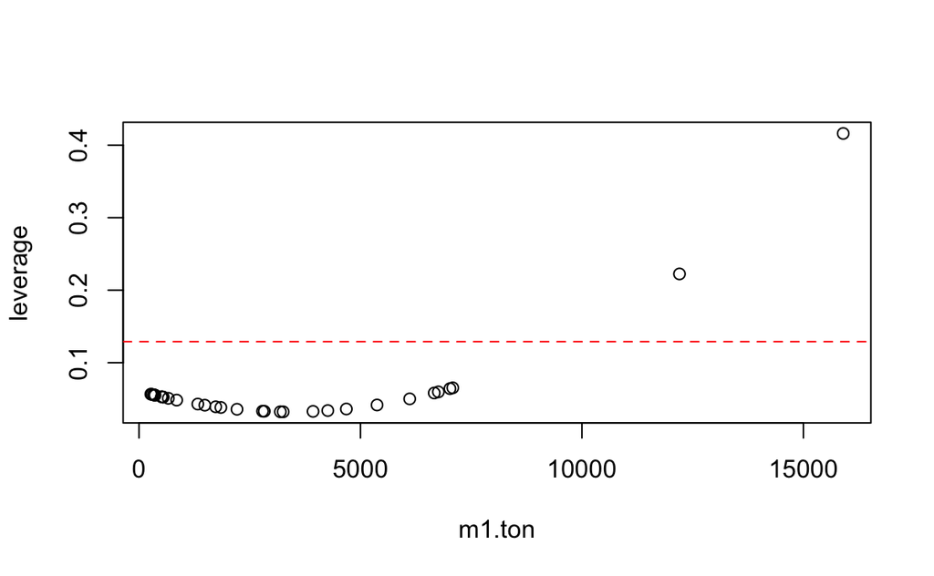

```r
# Compute leverage and Cook's distance
leverage <- hatvalues(model_M1)
cooksd <- cooks.distance(model_M1)

m1.ton <- data$Tonnage

#ploting the influtional measures against their x valuses
n=31
plot(leverage ~ m1.ton)
abline(h = 4 / n, col = "red", lty = 2)
```

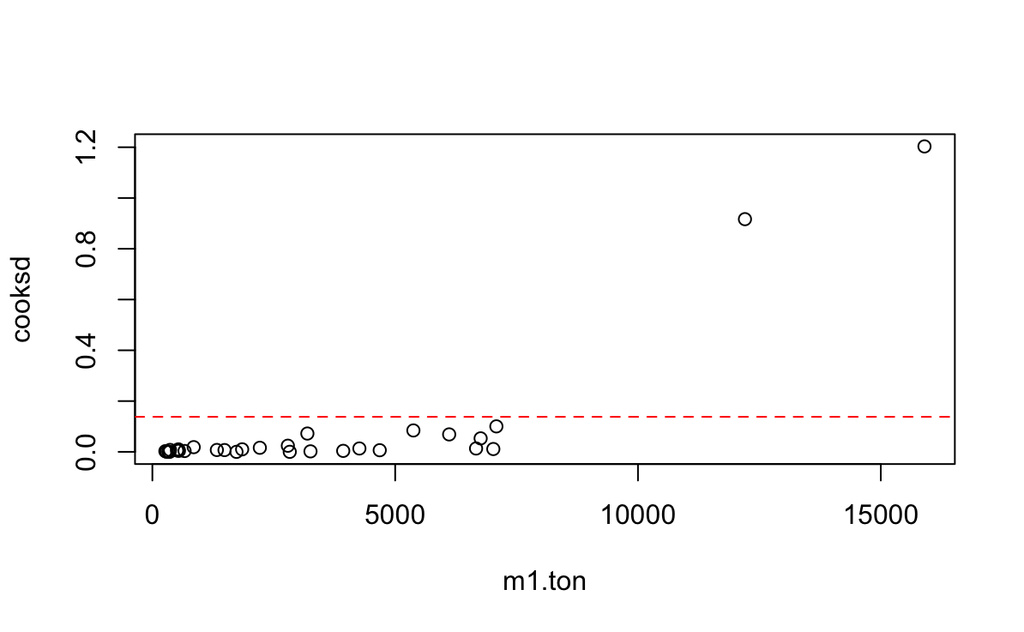

```r
plot(cooksd ~ m1.ton)
abline(h = 4 / (n-2), col = "red", lty = 2)
```

```r
sort(leverage)
```

```
         2          6         12         19         17         13          1
0.03232151 0.03238220 0.03290764 0.03310826 0.03322488 0.03402327 0.03582590
         8         14         25         27         10         22         29
0.03620318 0.03831051 0.03924776 0.04143837 0.04170692 0.04300258 0.04847106
         9         15          7         28          5         26         20
0.05015623 0.05093432 0.05254107 0.05269687 0.05279633 0.05311049 0.05522568
        18         16         23         24         11         30          4
0.05537637 0.05574001 0.05627542 0.05667705 0.05826937 0.05979601 0.06426313
        21          3         31
0.06539168 0.22243513 0.41614079
```

```r
sort(cooksd)
```

```
          25           18           19           23           16            2
2.492715e-05 3.406491e-05 9.502807e-05 4.388706e-04 6.055203e-04 1.918289e-03
          24           15           12            7           26            5
2.659065e-03 3.319869e-03 3.904257e-03 4.276945e-03 5.593141e-03 5.904395e-03
           8           27           22           20           28           14
6.415396e-03 7.020666e-03 7.384889e-03 7.561143e-03 9.739018e-03 9.898655e-03
           4           11           13            1           29           17
1.113477e-02 1.324320e-02 1.327780e-02 1.606459e-02 1.848780e-02 2.414799e-02
          30            9            6           10           21            3
5.310061e-02 6.868758e-02 7.213013e-02 8.436596e-02 1.003465e-01 9.166137e-01
          31
1.203196e+00
```

```r
# Plot leverage vs. standardized residuals
plot(residuals(model_M1, type = "studentized"), leverage, xlab = "Standardized Residuals", ylab = "Leverage", main = "Residuals vs. Leverage")
```

[output not shown]

Comment: The analysis identifies outliers and influential points based on leverage and Cook’s distance. Outliers are data points with standardized residuals outside the range (-2, 2), while influential points are those with high leverage and/or high Cook’s distance. These points may have a significant impact on the model fit and should be investigated further to determine if they should be included or excluded in the analysis.

4. (4 marks) Fit a regression model to the transformed $M_2$ model. Present the appropriate scatterplot and plot the fitted line onto the scatterplot. Does the transformed line regression model $M_2$ seem to fit the data well? Comment about the output in a few concise sentences.

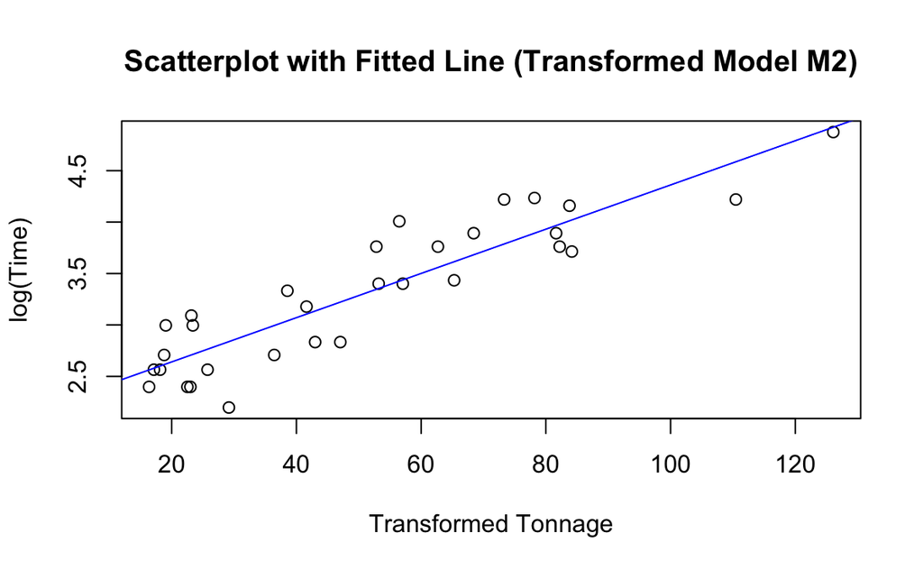

```r
# Transform the predictor variable according to the transformation in M2
data$Tonnage_transformed <- sqrt(data$Tonnage)

# Fit the regression model to the transformed predictor variable
model_M2 <- lm(log(Time) ~ Tonnage_transformed, data = data)

# Scatterplot with the transformed predictor variable and fitted line
plot(data$Tonnage_transformed, log(data$Time), main = "Scatterplot with Fitted Line (Transformed Model M2)",
     xlab = "Transformed Tonnage", ylab = "log(Time)")
abline(model_M2, col = "blue")
```

Comment: The scatterplot with the fitted line from the transformed model $M_2$ suggests that the transformed regression model might fit the data better than the simple linear model. The fitted line appears to capture the trend in the data more closely, indicating that the transformation has helped to better approximate the relationship between the predictor variable (transformed tonnage) and the response variable (time). However, further assessment of model assumptions and diagnostics would be necessary to make a definitive conclusion about the adequacy of the transformed model.

5. (5 marks) Provide the model summary and diagnostics checking plots for model $M_2.$ Does the straight line regression model $M_2$ seem to fit the data well? Comment about the output in a few concise sentences.

```
Call:
lm(formula = log(Time) ~ Tonnage_transformed, data = data)

Residuals:
    Min      1Q  Median      3Q     Max
-0.6408 -0.2522 -0.0357  0.2457  0.5814

Coefficients:
                    Estimate Std. Error t value Pr(>|t|)
(Intercept)         2.210424   0.111580   19.81  < 2e-16 ***
Tonnage_transformed 0.021514   0.001909   11.27  4.1e-12 ***
---
Signif. codes:  0 ‘***’ 0.001 ‘**’ 0.01 ‘*’ 0.05 ‘.’ 0.1 ‘ ’ 1

Residual standard error: 0.3048 on 29 degrees of freedom
Multiple R-squared:  0.8141,    Adjusted R-squared:  0.8077
F-statistic:   127 on 1 and 29 DF,  p-value: 4.098e-12
```

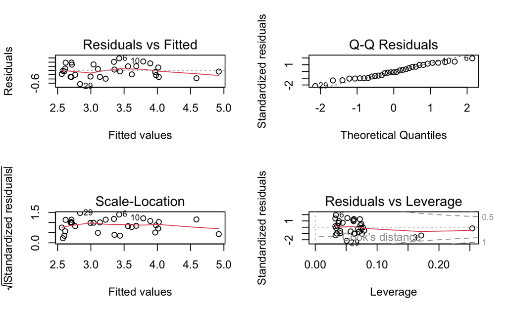

1. **Coefficient of determination ($R^2$)**: Indicates the proportion of variance in the dependent variable explained by the independent variable(s). Higher $R^2$ values suggest better explanatory power.
2. **Residual standard error**: Measures the average deviation of the observed values from the fitted values. Lower values indicate better fit.
3. **F-statistic and associated p-value**: Indicates the overall significance of the model. Lower p-values suggest better significance.

**Model with Tonnage as the predictor:** - $R^2$: 0.8386 - Residual standard error: 10.7 - F-statistic: 150.7, p-value: 5.218e-13

6. (4 marks) Perform a hypothesis testing for a positive slope at a significance level of 5% based on model $M_2.$

```
critical_value:  -1.699127
t_stat:  11.27
p_value:  4.097893e-12

Reject the null hypothesis: There is evidence of a positive slope at a significance level of 5%.
```

To perform a hypothesis test for a positive slope in model $M_2$ at a significance level of 5%, we need to test whether the coefficient estimate for the predictor variable $Tonnage^{0.5}$ is significantly different from zero.

The hypotheses are:

- Null hypothesis ($H_0$): The coefficient of $Tonnage^{0.5}$ ($\beta_1$) is zero.
- Alternative hypothesis ($H_1$): The coefficient of $Tonnage^{0.5}$ ($\beta_1$) is greater than zero.

We can use the t-test to test this hypothesis. If the p-value associated with the coefficient estimate of $Tonnage^{0.5}$ is less than 0.05, we reject the null hypothesis in favor of the alternative hypothesis, indicating evidence of a positive slope.

The coefficient estimate for $Tonnage^{0.5}$ in model $M_2$ represents the slope of the relationship between the square root of tonnage and the logarithm of time. We will check the p-value associated with this coefficient estimate. If the p-value is less than 0.05, we will reject the null hypothesis and conclude that there is evidence of a positive slope in the relationship.

7. (6 marks) Compare a 95% confidence interval of the mean response and a 95% prediction interval for a new value when Tonnage = 10,000 using the untransformed model $M_1$ and transformed model $M_2$ respectively. Provide two scatterplots that consist the fitted model, the confidence and prediction intervals for each of $M_1$ and $M_2$ respectively. Comment about the output in a few concise sentences.

```r
# Define the tonnage value for prediction
new_tonnage <- 10000

# Confidence interval for M1
conf_interval_M1 <- predict(model_M1, newdata = data.frame(Tonnage = new_tonnage), interval = "confidence", level = 0.95)

# Prediction interval for M1
pred_interval_M1 <- predict(model_M1, newdata = data.frame(Tonnage = new_tonnage), interval = "prediction", level = 0.95)

# Confidence interval for M2
# Transform the tonnage value according to the transformation in M2
new_tonnage_transformed <- sqrt(new_tonnage)
# Predict on the transformed scale
conf_interval_M2_transformed <- predict(model_M2, newdata = data.frame(Tonnage_transformed = new_tonnage_transformed), interval = "confidence", level = 0.95)
# Transform the intervals back to the original scale
conf_interval_M2 <- exp(conf_interval_M2_transformed)

# Prediction interval for M2
pred_interval_M2_transformed <- predict(model_M2, newdata = data.frame(Tonnage_transformed = new_tonnage_transformed), interval = "prediction", level = 0.95)
# Transform the intervals back to the original scale
pred_interval_M2 <- exp(pred_interval_M2_transformed)

# Plot for M1
plot(data$Tonnage, data$Time, xlab = "Tonnage", ylab = "Time", main = "Scatterplot with Intervals (Model M1)")
abline(model_M1, col = "red")  # Add the fitted line
```

```r
# Add confidence interval
matpoints(rep(new_tonnage, 2), conf_interval_M1[,2:3], lty = c(1, 2, 2), col = c("black", "red", "red"), type = "l")
# Add prediction interval
matpoints(rep(new_tonnage, 2), pred_interval_M1[,2:3], lty = c(1, 2, 2), col = c("black", "blue", "blue"), type = "l")
```

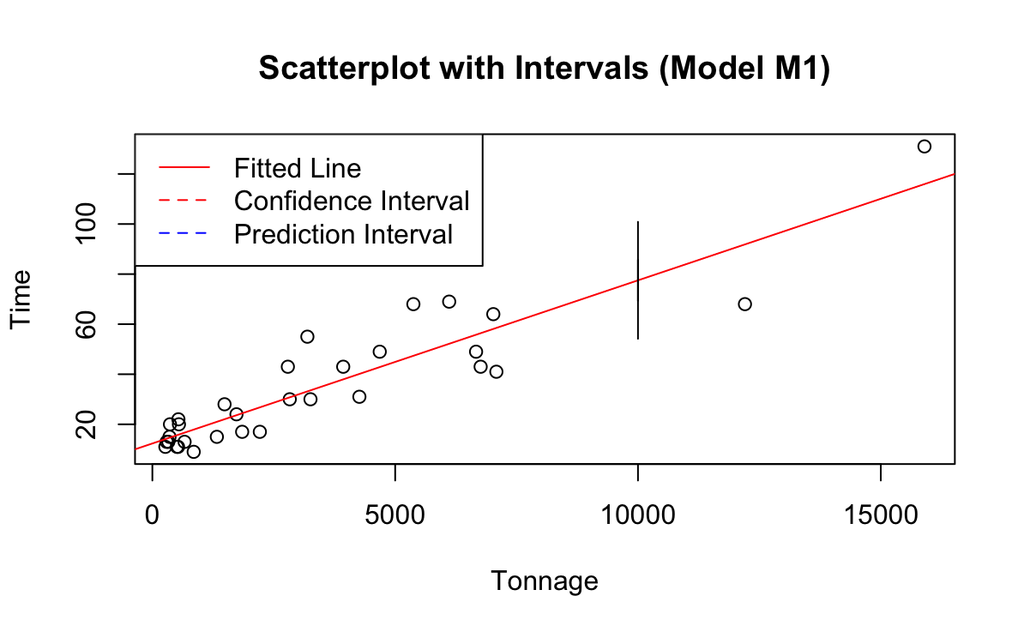

```r
legend("topleft", legend = c("Fitted Line", "Confidence Interval", "Prediction Interval"),
       col = c("red", "red", "blue", "blue"), lty = c(1, 2, 2))
```

```r
# Plot for M2
plot(data$Tonnage, data$Time, xlab = "Tonnage", ylab = "Time", main = "Scatterplot with Intervals (Model M2)")
abline(model_M2, col = "red")  # Add the fitted line
```

```r
# Add confidence interval
matpoints(rep(new_tonnage, 2), conf_interval_M2[,2:3], lty = c(1, 2, 2), col = c("black", "red", "red"), type = "l")
# Add prediction interval
matpoints(rep(new_tonnage, 2), pred_interval_M2[,2:3], lty = c(1, 2, 2), col = c("black", "blue", "blue"), type = "l")
```

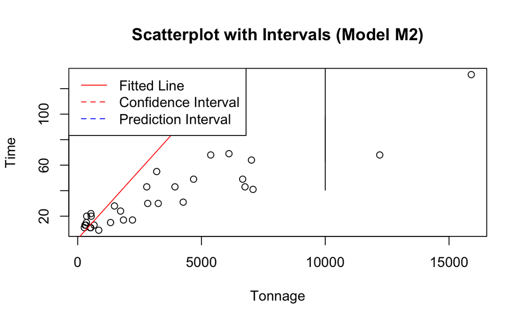

```r
legend("topleft", legend = c("Fitted Line", "Confidence Interval", "Prediction Interval"),
       col = c("red", "red", "blue", "blue"), lty = c(1, 2, 2))
```

```r
NA
NA
```

```r
# Define the tonnage value for prediction
new_tonnage <- 10000

# Confidence interval for M1
conf_interval_M1 <- predict(model_M1, newdata = data.frame(Tonnage = new_tonnage), interval = "confidence", level = 0.95)

# Prediction interval for M1
pred_interval_M1 <- predict(model_M1, newdata = data.frame(Tonnage = new_tonnage), interval = "prediction", level = 0.95)

# Confidence interval for M2
# Transform the tonnage value according to the transformation in M2
new_tonnage_transformed <- sqrt(new_tonnage)
# Predict on the transformed scale
conf_interval_M2_transformed <- predict(model_M2, newdata = data.frame(Tonnage_transformed = new_tonnage_transformed), interval = "confidence", level = 0.95)
# Transform the intervals back to the original scale
conf_interval_M2 <- exp(conf_interval_M2_transformed)

# Prediction interval for M2
pred_interval_M2_transformed <- predict(model_M2, newdata = data.frame(Tonnage_transformed = new_tonnage_transformed), interval = "prediction", level = 0.95)
# Transform the intervals back to the original scale
pred_interval_M2 <- exp(pred_interval_M2_transformed)

# Plot for M1
plot(data$Tonnage, data$Time, xlab = "Tonnage", ylab = "Time", main = "Scatterplot with Intervals (Model M1)")
abline(model_M1, col = "red")  # Add the fitted line
```

```r
# Add confidence interval
lines(rep(new_tonnage, 2), conf_interval_M1[,2:3], col = "blue", lty = 2)
# Add prediction interval
lines(rep(new_tonnage, 2), pred_interval_M1[,2:3], col = "green", lty = 2)
```

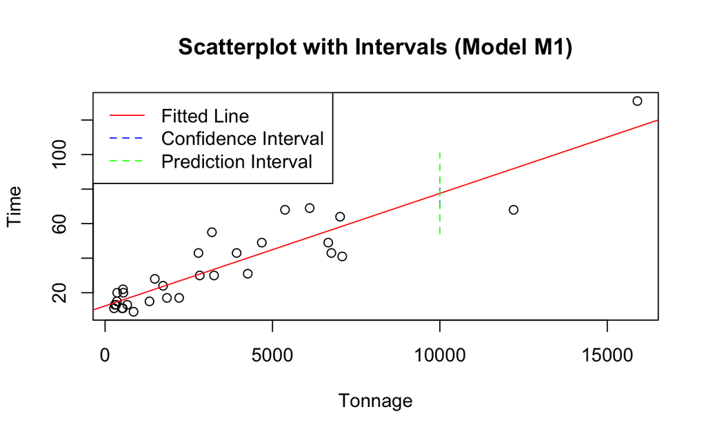

```r
legend("topleft", legend = c("Fitted Line", "Confidence Interval", "Prediction Interval"),
       col = c("red", "blue", "green"), lty = c(1, 2, 2))
```

```r
# Plot for M2
plot(data$Tonnage, data$Time, xlab = "Tonnage", ylab = "Time", main = "Scatterplot with Intervals (Model M2)")
abline(model_M2, col = "red")  # Add the fitted line
```

```r
# Add confidence interval
lines(rep(new_tonnage, 2), conf_interval_M2[,2:3], col = "blue", lty = 2)
# Add prediction interval
lines(rep(new_tonnage, 2), pred_interval_M2[,2:3], col = "green", lty = 2)
```

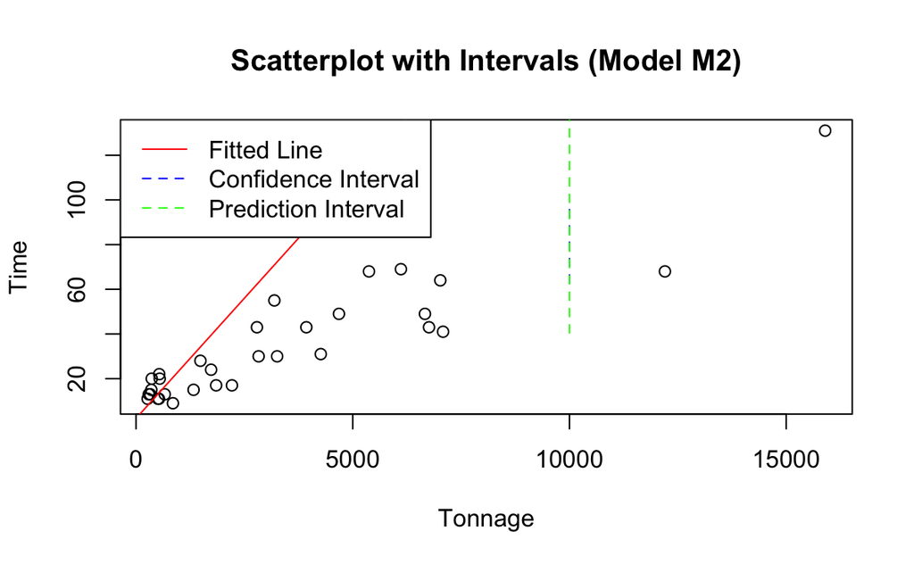

```r
legend("topleft", legend = c("Fitted Line", "Confidence Interval", "Prediction Interval"),
       col = c("red", "blue", "green"), lty = c(1, 2, 2))
```